# BayPass 2.3: tutoriel de génomique d’association adapté au séquençage en pool

Jérôme OLIVARES[^1]

2023-09-20

# Résumé

Ce tutoriel détaille d’une part la manière de générer les fichiers d’entrées du logiciel BayPass à partir de données de séquençage en pool, d’autre part le paramétrage optimal du logiciel BayPass et en fin propose une méthode d’exploreration des résultats d’analyses produits. Un pipeline d’analyse mixant des packages sous Rstudio et des lignes de commandes Linux, est décrit afin de guider pas à pas l’utilisateur tout au long du processus depuis les données brutes jusqu’à la liste finale de loci/variants candidats. Ce tutoriel est à destination des étudiants et des bioinformaticiens débutants.

### mots clefs

Logiciel BayPass, séquençage en pool, GWAS, études d’associations pangénomiques, Rstudio.

## prérequis

# Introduction

Dans un contexte agronomique actuel de réduction de l’utilisation des pesticides ou de réchauffement climatique, analyser et comprendre les bases génétiques de l’adaptation des organismes aux méthodes de luttes qui leurs sont opposées ou à l’évolution de leur environnement est un enjeu majeur des recherches de ces dernières années.

Les études d’associations pangénomiques (GWAS en anglais pour genome-wide association study) adossées aux techniques de séquençage haut débit (NGS) permettant le séquençage de génome complet, sont un outil de choix pour ce type d’analyse. L’étude au niveau populationnel demandant le séquençage d’un grand nombre d’individus, les couts d’analyses étaient initialement très élevés et ces études étaient souvent réservées aux organismes dit ‘‘modèles’’, humain en tête. Néanmoins il a été démontré depuis, que le séquençage en pool d’individus (poolseq) c’est-à-dire en mélangeant de manière équimolaire l’ADN d’un grand nombre d’individus (50 à 100) issus d’une même population permettait non seulement de réduire drastiquement les couts puisqu’on ne réalise qu’un seul séquençage mais aussi que la découverte des points de mutations (SNP) et l’estimation de leur fréquence allélique étaient souvent plus efficaces et précises (Futschik and Schlötterer 2010). Parmi les logiciels à même d’analyser ces fréquences alléliques on compte Baypass (Gautier 2015) qui évalue par une approche baysienne, la différenciation des SNP en liaison avec une covariable environnementale en tenant compte de la structure et de la parenté entre les populations en estimant la covariance (Ω) des fréquences alléliques. Baypass 2.3 a la particularité supplémentaire de pouvoir calculer un contraste des fréquences alléliques entre deux groupes de populations caractérisés par un caractère binaire, sensible ou résistant par exemple.

La documentation disponible de BayPass 2.3 décrit par le menu les algorithmes de fonctionnement et les différents paramètres du logiciel mais reste néanmoins, et assez logiquement, succincte sur les étapes en amont et en aval. A ma connaissance un seul tutoriel est disponible sur le web (Nielsen 2020) et décrit de manière plus détaillée la préparation des données brutes et l’analyse en mode « poolseq » de Baypass, mais il nécessite des bases quelque peu avancées de codage sous R et en environnement bash. Si les bio-informaticiens chevronnés ne rencontreront pas de difficultés particulières, il n’en va pas forcément de même pour bon nombre d’agents que les orientations des recherches associées à la baisse des coûts de séquençage ont aiguillé vers les voies de la génomique. Cet article a pour but de détailler les différentes étapes d’une analyse de type GWAS/poolseq avec le logiciel BayPass 2.3 et d’éclairer les points qui sont habituellement peu explicités car considérés comme évident.

# Présentation du logiciel BayPass 2.3

Le logiciel BayPass est un logiciel de génomique des populations qui vise principalement à l’identification de marqueurs génétiques soumis à la sélection et/ou associés à des covariables spécifiques à la population (variables environnementales, phénotypiques, quantitatives, catégorielles…). Par une approche baysienne il évalue une **matrice Ω** de covariance des fréquences alléliques des populations résultant de leur histoire démographique. Deux manières d’estimer ces fréquences alléliques sont disponibles soit en se basant sur les génotypes référence/mutant des individus analysés soit, lorsque l’on active le « pool-seq mode », ces fréquences alléliques sont calculées en regard de la profondeur de séquençage (reads count) et pondérées par le nombre d’individus qui ont contribué à cette profondeur. C’est cette seconde approche que nous considérerons dans cet ouvrage.

BayPass propose 3 modèles statistiques d’analyse :

#### Le Core Model

C’est le modèle de base, il permet de calculer la matrice de covariance Ω et d’attribuer une statistique de différenciation *XtX* à chaque SNP, et ainsi de scanner le génome pour identifier les régions génomiques différenciées entre les populations.Le *XtX* est défini comme la variance des fréquences alléliques standardisées du SNP dans les population, c’est une statistique analogue au Fst mais tient compte de la co-évolution des populations grace à la matrice Ω.

#### Le Standard Model

Ce modèle, permet, l’orsque l’on fournit une ou plusieurs covariables (environnementales, phénotypiques…), de calculer un facteur de Bayes, ou Bayes factor en anglais, (BF) pour chaque marqueur génétique représentant la force d’association avec une covariable. C’est un modèle tout en un qui intègre le calcul des XtX et de la matrice Ω, il est adapté au faible nombre de population (< 15).

#### L’Auxiliairy Model

Ce modèle a une approche différente dans le calcul de la statistique BF, sans entrer dans le détail il est plus adapté au grand nombre de population (> 15), En contrepartie il nécessite que l’on fournisse une matrice Ω déjà calculée par une analyse Core Model précédente, il recalcule alors les XtX et la statistique BF.

Ces covariables évoquées doivent être distribuées en gradient entre les populations (différence de température, d’altitude…), en complément, dans le cas où la covariable étudiée serait purement qualitative ou binaire (sensible/résistant, gros/petit…), les modèles Standard et Auxiliaire peuvent calculer une statistique C2 qui évalue le contraste de différence des fréquences alléliques de chaque marqueur entre 2 groupes de populations.

## Présentation générale de l’analyse :

La Figure 1 est une vision simplifiée des différentes étapes nécessaire à l’analyses de données poolseq. Les étapes nécessittant une importante puissance de calcul comme le variant calling ou l’analyse BayPass se déroulent soit dans l’environnement Linux du cluster de calcul, les étapes de filtrage, manipulation de données et de résultats se font sur ordinateur local sous Rstudio. La première étape part des fichiers d’alignement au format « *bam* » de chaque population à analyser et consiste à effectuer une recherche de variants (variant calling) pour obtenir un fichier au format « **vcf* » regroupant tous les points de mutations ou SNP de toutes les populations qui sont autant de marqueurs génétiques à analyser. Ce fichier *vcf* sert d’entrée au package « PoolFstat » (Gautier et al. 2022) qui va permettre de filtrer les SNPs à analyser et générer les fichiers nécessaires au bon fonctionnement de BayPass mais aussi de faire une première analyse des Fst entre populations par exemple. Ces fichiers d’entrées pouvant contenir plusieurs millions de SNP, ils sont découpés en plusieurs dizaines de sous jeux de données (sub sampling) afin de réduire les temps de calculs. Une fois que BayPass a analysé tous les sous jeux de données, l’homogénéité des résultats entre eux est analysée sous Rstudio puis les résultats peuvent être regroupés, filtrés et analysés afin de déterminer les marqueurs génétiques et les régions chromosomiques d’intérêts qui seront visualisées par différents plots.

Figure 1: Pipeline d’analyse BayPass

[figure not shown]

Le pipeline d’analyse est décomposé en plusieurs étapes se déroulant soit en environnement Linux pour celles nécessitant une importante capacité de calcul, soit sous Rstudio pour le filtrage et l’analyse des résultats.

# Données brutes

## Obtention d’un fichier Poolseq.vcf :

Les étapes de contrôle qualité et d’alignement des données de séquençage sont largement documentés par ailleurs, et ne serons donc pas documenter ici, et nous partirons directement des fichiers d’alignement *bam*. La première étape consiste à regrouper les fichiers *bam* de toutes les populations en un seul fichier puis à effectuer le variant calling avec un logiciel dédié compatible avec le séquençage en pool afin de conserver les informations de profondeur. Nous recommandons l’utilisation des Samtools (Li et al. 2009) et de Varscan 2 (Koboldt et al. 2012) avec une instruction pipe entre les deux pour éviter les fichiers intermédiaires et économiser l’espace de travail (Script 1). Les commandes sont effectuées avec les paramètres de base, sauf la p-value qui est montée à 0.5 pour être le moins stringent possible à ce stade. On peut découper le travail en plusieurs chromosomes pour réduire les temps de calculs.

**Script 1** Exemple d’un script bash pour effectuer un variant calling

Si l’on veut découper le travail en chromosomes, il est indispensable de travailler sur des fichiers bam correctement indexés et d’utiliser l’option -r/–region qui tire profit de cet index.

```bash
#!/bin/bash
#SBATCH --array=1-29            #création de l'array: un élément/indice par chromosome

module load bioinfo/samtools/1.12
module load bioinfo/VarScan/2.4.2
module load bioinfo/bcftools/1.14

#liste tous les fichiers "bam" et leur chemin
ls /../*.bam > BamList.txt
#extrait les noms des échantillons/populations
ls /../*.bam | sed -r 's/^.+\///' | sed -r 's/.bam//' > NameList.txt

samtools mpileup -C 50 -d 5000 -q 20 \
-r chr${SLURM_ARRAY_TASK_ID} \    #attribut un chr à chaque indice de l'array : chr1, chr2 ...
-f /../ref_genome.fas -b /../BamList.txt | \
java -Xmx2G -jar $VARSCAN mpileup2cns \
--variants --min-coverage 10 \
--min-avg-qual 20 --min-var-freq 0.05 \
--p-value 0.5 --output-vcf 1 \
--vcf-sample-list NameList.txt > /../project_chr${SLURM_ARRAY_TASK_ID}.vcf

bgzip /../project_chr${SLURM_ARRAY_TASK_ID}.vcf
bcftools index /../project_chr${SLURM_ARRAY_TASK_ID}.vcf
```

A l’issue du variant calling les fichiers *vcf* des autosomes seront concaténés (Script 2), les chromosomes sexuels ayant une ségrégation, une histoire démographique et une ploïdie différente des autosomes il conviendra, lorsque cela est possible, de les analyser à part.

**Script 2** Exemple d’un script bash pour concaténer des fichiers *vcf*

On peut utiliser les bcftools pour concaténer les fichier *vcf*, la liste des fichiers à traiter est contenue dans une variable alimentée par une boucle “for”.

```bash
#!/bin/bash
module load bioinfo/bcftools/1.14
my_path='/../'

# une boucle "for" itére sur les numéros des autosomes de 2 à 28
# et ajoute chaque fichier vcf et son chemin dans une variable
for ((i=2; i<=28; i++))
do
    files+=" $my_path/project_chr${i}.vcf.gz"
done

# bcftools concatène la liste des vcf contenu dans la variable $file
bcftools concat $files -O z -o $my_path/project_chr2-28.vcf.gz
```

## Filtrage des données brutes

Le fichier *vcf*, éventuellement compressé, est téléchargé sur un ordinateur local pour être analysé sous Rstudio. Dans un premier temps il faut charger les packages nécessaires et définir les chemins des différents dossiers qui seront utilisés (Chunk 1)

**Chunk 1** Chargement des packages et chemins

```r
library(poolfstat)      #filtrage du vcf et création des fichiers d'entrées BayPass
library(RColorBrewer)   #gestion couleur des heatmaps
library(mixOmics)       #"cim" pour heatmap
library(corrplot)       #matrice de corrélation pour heat map
library(VennDiagram)    #création de diagramme de Venn
library(nVennR)         #extraction de données d'un diagramme de Venn
library(tidyverse)      #manipulation de données (dplyr) et plots (ggplot2)

#définition des chemins de travail
path_vcf <- "/../vcf/"
path_input <- "/../Input/"
path_out <- "/../Output/"
path_res <- "/../Resultats/"
source("/../baypass_utils.R")   #fonctions utilitaires de BayPass
```

Le filtrage du *vcf* et la sélection des SNPs à analyser ce fait à l’aide du package PoolFstat (Chunk 2). Dans un premier temps il faut renseigner les noms des populations dans un objet *pnames* et les tailles haploïdes de chaque population dans un objet *psizes*. Pour les organismes diploïdes, le nombre total de copies des autosomes sera deux fois le nombre d’individus dans le pool, pour les gonosomes Y ou W la ploïdie sera égale au nombre d’individus XY/ZW et pour les gonosomes X ou Z le calcul sera (nombre de XX/ZZ * 2) + (nombre de XY/ZW * 1). La fonction *vcf2poodata* va balayer le fichier *vcf*, sélectionner les SNP bi-alléliques selon des critères définis par l’utilisateur et créer un objet *pooldata*.

**Chunk 2** Filtrage et sélection des SNPs

Les options à renseigner sont:  
min.cov.per.pool = Si au moins un pool n’est pas couvert par au moins au moins min.cov.perpool reads, le SNP est rejeté.  
max.cov.per.pool = Si au moins un pool est couvert par plus de que max.cov.perpool reads, le SNP est rejeté.  
min.maf = fréquence allélique minimale autorisée pour l’allèle minoritaire pour qu’un SNP soit retenu.

```r
#Infos sur les pops
pnames <- c("pop1S", "pop2S", "pop3S", "pop1R", "pop2R", "pop3R")
psizes_A <- c('114', '180', '160', '180', '200', '120')   #ploydie autosome
psizes_X <- c('86', '135', '120', '135', '150', '90')     #ploydie X/Z
psizes_Y <- c('28', '45', '40', '45', '50', '30')         #ploydie Y/W
#conversion du .vcf
pooldata <- vcf2pooldata(vcf.file = paste(path_vcf, "test_data.vcf.gz", sep=""),
                         poolsizes = psizes_A,
                         poolnames = pnames,
                         min.cov.per.pool = 4,
                         max.cov.per.pool = 1e+06,
                         min.maf = 0.05,
                         remove.indels = FALSE,
                         nlines.per.readblock = 1e+06)
```

```
## Reading Header lines
## VarScan like format detected for allele count data:
##  the AD field contains allele depth
## for the alternate allele and RD field for the reference allele
## (N.B., positions with more than one alternate allele will be ignored)
## Parsing allele counts
## 1e+06  lines processed in 0 h  0 m  19 s : 577119 SNPs found
## 1810324  lines processed in 0 h  0 m  32 s : 1066980 SNPs found
## Data consists of 1066980 SNPs for 6 Pools
```

```r
#élimine le 1% supérieur considéré comme trop fortement couvert
#(région très dupliquée, biais de séquençage...)
pooldata<-pooldata.subset(pooldata, cov.qthres.per.pool = c(0,0.99))
```

```
## Data consists of 1041408 SNPs for 6 Pools
```

A ce stade cet objet *pooldata* peut être utilisé pour calculer diverses statistiques utilisées dans les études de génomique des populations, ces outils sont décrits et exemplifiés dans la vignette de *poolfstat* : (https://cran.r-project.org/web/packages/poolfstat/vignettes/vignette.pdf), parmis ceux-ci on trouve l’analyse des Fst entre les populations deux à deux (pairwise) afin de visualiser la proximité génétique entre populations(Chunk 3).

**Chunk 3** Pairwise Fst

```r
#Calcul des pairwise Fst
PairWise.fst <- compute.pairwiseFST(pooldata,
                                    method = "Anova",
                                    min.cov.per.pool = 4,
                                    max.cov.per.pool = 1e+06,
                                    min.maf = 0.05,
                                    output.snp.values = FALSE,
                                    verbose = FALSE)
```

```
##
## Overall Analysis Time: 0 h 0 m 5 s
```

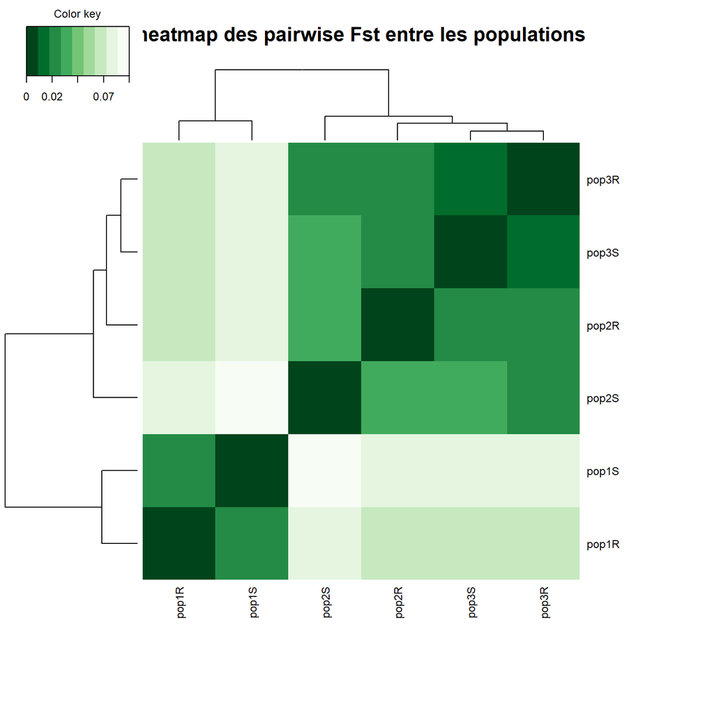

```r
#conversion en matrice de distance
df <- as.matrix(dist(t(PairWise.fst@PairwiseFSTmatrix)))
#heatmap
cim_color <- colorRampPalette(rev(brewer.pal(9, "Greens")))(9)
cim(df, color = cim_color, symkey = FALSE, margins = c(10, 10),  title = "heatmap des pairwise Fst entre les populations")
```

un exemple d’estimation de la structure génétique des populations déduite des Fst est donné en Annexe 1